# Assignment 2

Jocelyn Tsai

9/13/2020

I first loaded the tidyverse and ggplot2 libraries:

```r
library(tidyverse)
library(ggplot2)
```

I then loaded my dataset from Assignment 1. Referencing from Catherine’s example assignment, I used the “attach” function to connect my dataframe from Assignment 1 to the search path. Now I can refer to my variables without specifying the dataframe that they’re in every time.

```r
US_data <- read_csv("wildfire_dataset.csv")
attach(US_data)
```

List of variables from Assignment 1: (I am not showing “Year” as a variable in this assignment because it does that make sense to graph the distribution of “Year” since there’s only 1 value every year from 1929 to 2015)

1. Annual Rainfall in the US (continuous): Total_Rainfall_mm
2. Mean Annual Temperature in the US (continuous): Mean_Temp_Celsius
3. Number of Wildfires in the US each year (continuous): Num_Fires
4. Number of Acres Burned in the US each year (continuous): Acres_Burned
5. Years with Extreme Heat Wave in the US (categorical): Extreme_Heat_Wave
6. Years with High Unemployment in the US (categorical): High_Unemployment

## 1. Statistics in a Table for All Continuous Variables

Statistics include: sample mean, median, standard deviation, inter-quartile range, 95-percent confidence interval for population mean

I used the summary() function to get a quick distribution summary for each of the continuous variables. Since the summary () function does not include standard deviation and it cannot find the 95 percent confidence interval, I also used the sd() and t.test() functions. I then combined the cleaned up statistic values using prettyNum() into a list for each variable.

### Continuous Variable 1: Annual Rainfall (mm) in the US

```r
summary(Total_Rainfall_mm)
```

```
##    Min. 1st Qu.  Median    Mean 3rd Qu.    Max.
##   558.3   627.3   651.8   649.7   676.3   761.6
```

```r
rain_summary <- summary(Total_Rainfall_mm)
rain_sd <- sd(Total_Rainfall_mm)
rain_95confidence <- t.test(Total_Rainfall_mm)
```

```r
annual_rainfall <- c(prettyNum(rain_summary["Mean"], digits =4),
                     prettyNum(rain_summary["Median"], digits =4),
                     prettyNum(rain_sd, digits = 4),
                     paste(prettyNum(rain_summary["1st Qu."], digits =4), "to",                                             prettyNum(rain_summary["3rd Qu."], digits =4)),
                     paste(prettyNum(rain_95confidence$conf.int[1], digits=4), "to",
                           prettyNum(rain_95confidence$conf.int[2], digits=4)))
annual_rainfall
```

```
##             Mean           Median
##          "649.7"          "651.8"          "41.96" "627.3 to 676.3"
##
## "640.8 to 658.7"
```

### Continuous Variable 2: Mean Annual Temperature (celsius) in the US

```r
summary(Mean_Temp_Celsius)
```

```
##    Min. 1st Qu.  Median    Mean 3rd Qu.    Max.
##   6.302   6.722   7.064   7.104   7.490   8.481
```

```r
temp_summary <- summary(Mean_Temp_Celsius)
temp_sd <- sd(Mean_Temp_Celsius)
temp_95confidence <- t.test(Mean_Temp_Celsius)
```

```r
mean_annual_temp <- c(prettyNum(temp_summary["Mean"], digits =3),
                      prettyNum(temp_summary["Median"], digits =3),
                      prettyNum(temp_sd, digits = 3),
                      paste(prettyNum(temp_summary["1st Qu."], digits =3), "to",                                             prettyNum(temp_summary["3rd Qu."], digits =3)),
                      paste(prettyNum(temp_95confidence$conf.int[1], digits=3), "to",
                            prettyNum(temp_95confidence$conf.int[2], digits=3)))
mean_annual_temp
```

```
##           Mean         Median
##          "7.1"         "7.06"        "0.497" "6.72 to 7.49"    "7 to 7.21"
```

### Continuous Variable 3: Number of Wildfires in the US each year

```r
summary(Num_Fires)
```

```
##    Min. 1st Qu.  Median    Mean 3rd Qu.    Max.
##   18229   80075  117957  126770  173138  249370
```

```r
num_fire_summary <- summary(Num_Fires)
num_fire_sd <- sd(Num_Fires)
num_fire_95confidence <- t.test(Num_Fires)
```

```r
num_fire <- c(prettyNum(num_fire_summary["Mean"], digits =3),
              prettyNum(num_fire_summary["Median"], digits =3),
              prettyNum(num_fire_sd, digits = 3),
              paste(prettyNum(num_fire_summary["1st Qu."], digits =3), "to",                                         prettyNum(num_fire_summary["3rd Qu."], digits =3)),
              paste(prettyNum(num_fire_95confidence$conf.int[1], digits=3), "to",
                    prettyNum(num_fire_95confidence$conf.int[2], digits=3)))
num_fire
```

```
##               Mean             Median
##           "126770"           "117957"            "55922"  "80075 to 173138"
##
## "114852 to 138689"
```

### Continuous Variable 4: Number of Acres Burned in the US each year

```r
summary(Acres_Burned)
```

```
##     Min.  1st Qu.   Median     Mean  3rd Qu.     Max.
##  1148409  3279282  5260825 11477719 14792000 52266000
```

```r
acres_burned_summary <- summary(Acres_Burned)
acres_burned_sd <- sd(Acres_Burned)
acres_burned_95confidence <- t.test(Acres_Burned)
```

```r
burned <- c(prettyNum(acres_burned_summary["Mean"], digits =3),
            prettyNum(acres_burned_summary["Median"], digits =3),
            prettyNum(acres_burned_sd, digits = 3),
            paste(prettyNum(acres_burned_summary["1st Qu."], digits =3), "to",                                     prettyNum(acres_burned_summary["3rd Qu."], digits =3)),
            paste(prettyNum(acres_burned_95confidence$conf.int[1], digits=3), "to",
                  prettyNum(acres_burned_95confidence$conf.int[2], digits=3)))
burned
```

```
##                  Mean                Median
##            "11477719"             "5260825"            "13050569"
##
## "3279282 to 14792000" "8696266 to 14259173"
```

### Display all four continuous variables in a formmated table:

```r
stats <- c("Sample Mean",
                "Median",
                "Standard Deviation",
                "Interquartile Range",
                "95% Confidence Interval (Population Mean)")
stats
```

```
## [1] "Sample Mean"
## [2] "Median"
## [3] "Standard Deviation"
## [4] "Interquartile Range"
## [5] "95% Confidence Interval (Population Mean)"
```

```r
summary_table <- tibble("Statistics" =stats,
       "Annual Rainfall (mm)" =annual_rainfall,
       "Mean Annual Temperature (celsius)" =mean_annual_temp,
       "Number of Fires (per year)" =num_fire,
       "Acres Land Burned (per year)" =burned)
summary_table
```

```
## # A tibble: 5 x 5
##   Statistics `Annual Rainfal… `Mean Annual Te… `Number of Fire… `Acres Land Bur…
##   <chr>      <chr>            <chr>            <chr>            <chr>
## 1 Sample Me… 649.7            7.1              126770           11477719
## 2 Median     651.8            7.06             117957           5260825
## 3 Standard … 41.96            0.497            55922            13050569
## 4 Interquar… 627.3 to 676.3   6.72 to 7.49     80075 to 173138  3279282 to 1479…
## 5 95% Confi… 640.8 to 658.7   7 to 7.21        114852 to 138689 8696266 to 1425…
```

```r
knitr::kable(summary_table, caption= "Statistics of Yearly Environmental Data in the US")
```

Statistics of Yearly Environmental Data in the US

| Statistics | Annual Rainfall (mm) | Mean Annual Temperature (celsius) | Number of Fires (per year) | Acres Land Burned (per year) |
| --- | --- | --- | --- | --- |
| Sample Mean | 649.7 | 7.1 | 126770 | 11477719 |
| Median | 651.8 | 7.06 | 117957 | 5260825 |
| Standard Deviation | 41.96 | 0.497 | 55922 | 13050569 |
| Interquartile Range | 627.3 to 676.3 | 6.72 to 7.49 | 80075 to 173138 | 3279282 to 14792000 |
| 95% Confidence Interval (Population Mean) | 640.8 to 658.7 | 7 to 7.21 | 114852 to 138689 | 8696266 to 14259173 |

## 2. Histogram of Distribution for each Continuous Variable

### Continuous Variable 1: Annual Rainfall (mm) in the US

1. Sample Mean: 649.7
2. Median: 651.8
3. Standard Deviation: 41.96
4. Interquartile Range: 627.3 to 676.3
5. 95% Confidence Interval: 640.8 to 658.7

The distribution of Annual Rainfall is slightly skewed to the left, with a median larger than the sample mean. There is only one outlier (a year) that has extreme rainfall of more than 750 milimeters comparing to other years.

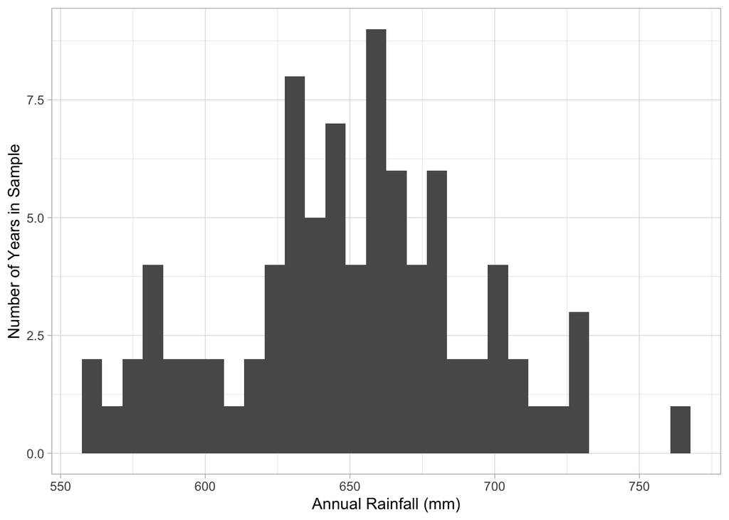

```r
rain_hist <- ggplot(US_data, aes(x= Total_Rainfall_mm))+
  geom_histogram()

rain_hist+
  theme_light()+
  scale_x_continuous(name= "Annual Rainfall (mm)")+
  scale_y_continuous(name= "Number of Years in Sample")
```

### Continuous Variable 2: Mean Annual Temperature (celsius) in the US

1. Sample Mean: 7.1
2. Median: 7.06
3. Standard Deviation: 0.497
4. Interquartile Range: 6.72 to 7.49
5. 95% Confidence Interval: 7 to 7.21

The distribution of Mean Annual Temperature is slightly skewed to the right, with a mean larger than the median. Values above 7.5 bring the average of the distribution up, while more observations are concentrated on the left side.

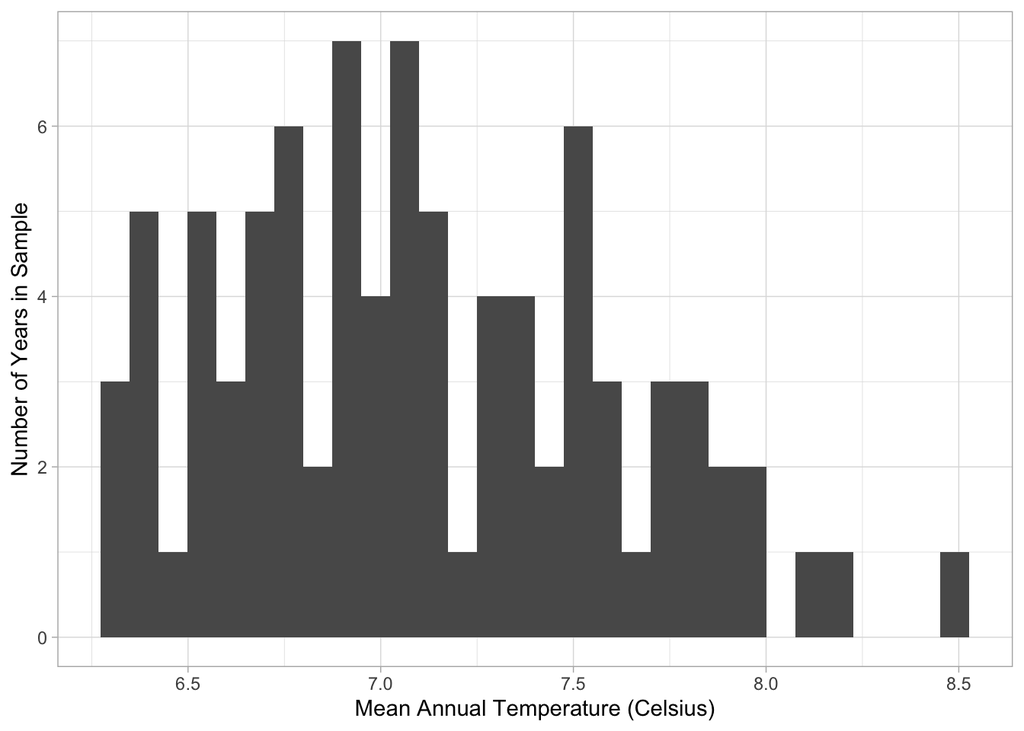

```r
temp_hist <- ggplot(US_data, aes(x= Mean_Temp_Celsius))+
  geom_histogram()

temp_hist+
  theme_light()+
  scale_x_continuous(name= "Mean Annual Temperature (Celsius)")+
  scale_y_continuous(name= "Number of Years in Sample")
```

### Continuous Variable 3: Number of Wildfires in the US each year

1. Sample Mean: 126770
2. Median: 117957
3. Standard Deviation: 55922
4. Interquartile Range: 80075 to 173138
5. 95% Confidence Interval: 114852 to 138689

The distribution of the Number of Wildfires is skewed to the right, with a mean larger than the median. There is a greater number of observations closer to the left side of the histogram.

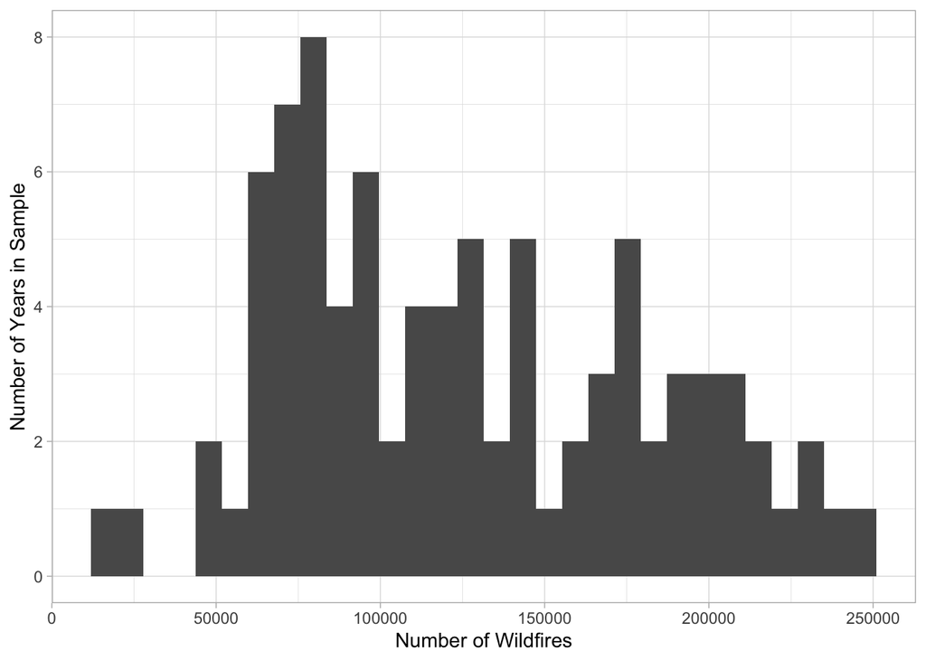

```r
fires_hist <- ggplot(US_data, aes(x= Num_Fires))+
  geom_histogram()

fires_hist+
  theme_light()+
  scale_x_continuous(name= "Number of Wildfires")+
  scale_y_continuous(name= "Number of Years in Sample")
```

### Continuous Variable 4: Number of Acres Burned in the US each year

1. Sample Mean: 11477719
2. Median: 5260825
3. Standard Deviation: 13050569
4. Interquartile Range: 3279282 to 14792000
5. 95% Confidence Interval: 8696266 to 14259173

The sample mean is significantly larger than the median, so the histogram is skewed positively to the right. There is a long tail trailing on the right side of the graph, bringing the average of the distribution higher.

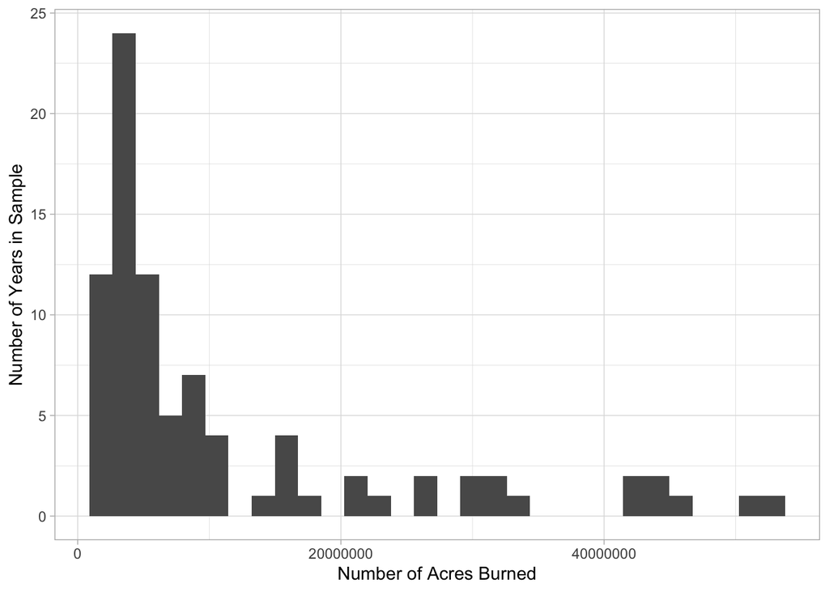

```r
options(scipen = 999)
burned_hist <- ggplot(US_data, aes(x= Acres_Burned))+
  geom_histogram()

burned_hist+
  theme_light()+
  scale_x_continuous(name= "Number of Acres Burned")+
  scale_y_continuous(name= "Number of Years in Sample")
```

## 3. Categorical Variables

### Categorical Variable 1: Years with Extreme Heat Wave

I first used table() to get the number of observations in each category:

```r
table(US_data$Extreme_Heat_Wave)
```

```
##
## FALSE  TRUE
##    75    12
```

I calculated the proportion of the sample (years) that has Extreme Heat Wave:

```r
mean(US_data$Extreme_Heat_Wave == "TRUE")
```

```
## [1] 0.137931
```

I then used the t.test() function to get the 95 percent confidence interval for the proportion that has extreme heat wave.

```r
t.test(US_data$Extreme_Heat_Wave == "TRUE")
```

```
##
##  One Sample t-test
##
## data:  US_data$Extreme_Heat_Wave == "TRUE"
## t = 3.7094, df = 86, p-value = 0.0003674
## alternative hypothesis: true mean is not equal to 0
## 95 percent confidence interval:
##  0.06401226 0.21184981
## sample estimates:
## mean of x
##  0.137931
```

Here is a bar chart showing the number of years that have extreme heat wave versus years without extreme heat wave.

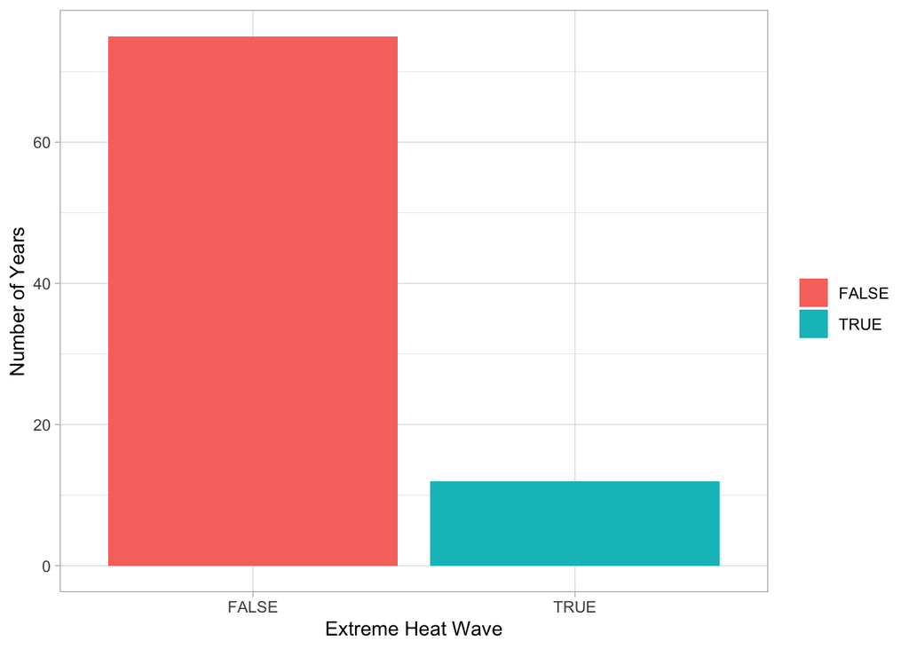

```r
ggplot(US_data, aes(x = Extreme_Heat_Wave, fill= Extreme_Heat_Wave)) +
  geom_bar() +
  scale_y_continuous(name = "Number of Years") +
  scale_x_discrete(name = "Extreme Heat Wave",
                       labels = c("FALSE",
                                  "TRUE")) +
  scale_fill_discrete(name = element_blank(),
                        labels = c("FALSE",
                                   "TRUE")) +
  theme_light()
```

### Categorical Variable 2: Years with High Unemployment

I first used table() to get the number of observations in each category:

```r
table(US_data$High_Unemployment)
```

```
##
## FALSE  TRUE
##    30    57
```

I calculated the proportion of the sample (years) that has High Unemployment:

```r
mean(US_data$High_Unemployment == "TRUE")
```

```
## [1] 0.6551724
```

```r
t.test(US_data$High_Unemployment == "TRUE")
```

```
##
##  One Sample t-test
##
## data:  US_data$High_Unemployment == "TRUE"
## t = 12.783, df = 86, p-value < 0.00000000000000022
## alternative hypothesis: true mean is not equal to 0
## 95 percent confidence interval:
##  0.5532824 0.7570624
## sample estimates:
## mean of x
## 0.6551724
```

Here is a bar chart showing the number of years that have high unemployment rate versus years that don’t have high unemployment rate.

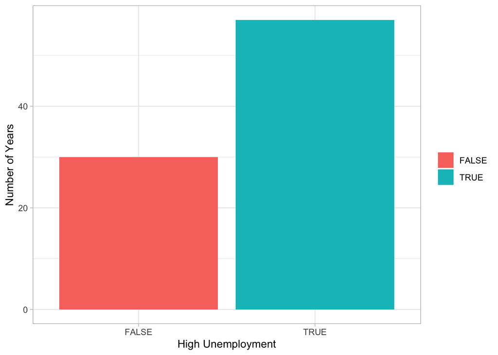

```r
ggplot(US_data, aes(x = High_Unemployment, fill= High_Unemployment)) +
  geom_bar() +
  scale_y_continuous(name = "Number of Years") +
  scale_x_discrete(name = "High Unemployment",
                       labels = c("FALSE",
                                  "TRUE")) +
  scale_fill_discrete(name = element_blank(),
                        labels = c("FALSE",
                                   "TRUE")) +
  theme_light()
```